# 04_phylogeny

Ri Desroches

2024-04-30

# Setup

## load packages

```r
pacman::p_load(phytools, ggtree, RColorBrewer, tidyverse, phyloseq, microViz, install = FALSE)
install.packages(
  "microViz",
  repos = c(davidbarnett = "https://david-barnett.r-universe.dev", getOption("repos"))
)
```

## set seed

```r
set.seed(0110)
```

## load data

```r
load("data/02_preprocessing/cleaned_physeq.RData")
clean_physeq <- nochlorosmito_physeq

#just renaming variable for ease of coding throughout
```

# File goals

1. Create ASV fasta file from phyloseq obj
2. Align 16S sequences with MAFFT
3. Create an unrooted tree with fasttree2
4. Save tree file
5. Add tree to phyloseq object
6. Visualize with ggtree
7. Root tree and merge with phyloseq
8. Save rooted tree

# Alignment and unrooted tree

## Create ASV Fasta file

```r
# data frame of asvs and asv names

colnames(clean_physeq@tax_table)
```

```
## [1] "Kingdom" "Phylum"  "Class"   "Order"   "Family"  "Genus"   "Species"
## [8] "ASV"     "ASVSeq"
```

```r
asv_seq_df <-
  clean_physeq@tax_table %>%
  data.frame()%>%
  dplyr::select(ASV,ASVSeq)

# Make fasta headers
asv_seq_df$ASV <- paste0(">", asv_seq_df$ASV)

#create fasta object
asv_seq_fasta <- c(rbind(asv_seq_df$ASV, asv_seq_df$ASVSeq))
head(asv_seq_fasta)
```

```
## [1] ">ASV_1"
## [2] "CAGCCGCGGTAATACGTAGGGTGCGAGCGTTGTCCGGAATTACTGGGCGTAAAGAGCTCG…"
## [3] ">ASV_2"
## [4] "CAGCCGCGGTAATACGTAGGGTGCGAGCGTTGTCCGGAATTACTGGGCGTAAAGAGCTCG…"
## [5] ">ASV_3"
## [6] "CAGCCGCGGTAATACGTAGGGTGCGAGCGTTGTCCGGAATTACTGGGCGTAAAGAGCTCG…"
```

```r
#in fasta format

# write to a file
write(asv_seq_fasta,
      file="data/04_phylogeny/asv_seqs.fasta")
```

## Align 16S sequences in fasta file

Note: need to run bash code for this step

```bash
# provide path to mafft
#export PATH=/programs/mafft/bin:$PATH
# change directories to fasta file
#cd data/04_phylogeny/
#pwd

# set seed
#RANDOM=0110

# Run mafft
#/programs/mafft/bin/mafft --auto asv_seqs.fasta > mafft_aligned_asvs.fasta

# back to project directory
#cd ../../
#pwd
```

## FastTree2

More bash code

```bash
# fasttree export path
#export PATH=/programs/FastTree-2.1.11:$PATH

#switch directory
#cd data/04_phylogeny/

#run fasttree
#dataset is very large, use fastest

#FastTree -nt -gtr -fastest -log FastTree.log mafft_aligned_asvs.fasta > asvs_unrooted.tree

#cd to main directory
#cd ../../
#pwd
```

# Inspect, prune, and root tree

## load in tree

```r
unrooted_tree <- read.tree("data/04_phylogeny/asvs_unrooted.tree")
unrooted_tree
```

```
##
## Phylogenetic tree with 35337 tips and 35335 internal nodes.
##
## Tip labels:
##   ASV_1972, ASV_4009, ASV_1476, ASV_313, ASV_1004, ASV_14664, ...
## Node labels:
##   , 0.922, 0.174, 0.922, 0.922, 0.929, ...
##
## Unrooted; includes branch lengths.
```

## merge phyloseq

```r
unrooted_physeq <-
  merge_phyloseq(clean_physeq, unrooted_tree)

unrooted_physeq
```

```
## phyloseq-class experiment-level object
## otu_table()   OTU Table:         [ 35337 taxa and 72 samples ]
## sample_data() Sample Data:       [ 72 samples by 46 sample variables ]
## tax_table()   Taxonomy Table:    [ 35337 taxa by 9 taxonomic ranks ]
## phy_tree()    Phylogenetic Tree: [ 35337 tips and 35335 internal nodes ]
```

## plot tree with ggtree

```r
kingdomtree <-
  ggtree(unrooted_physeq)  +
  geom_tippoint(mapping = aes(color = Kingdom)) +
  scale_color_manual(values = c("pink", "maroon", "grey")) +
  labs(title = "Unrooted Tree") +
  theme(legend.position = "bottom")
```

This tree looks horrible!!!!!

## Inspect tree more closely and ID some grey nodes

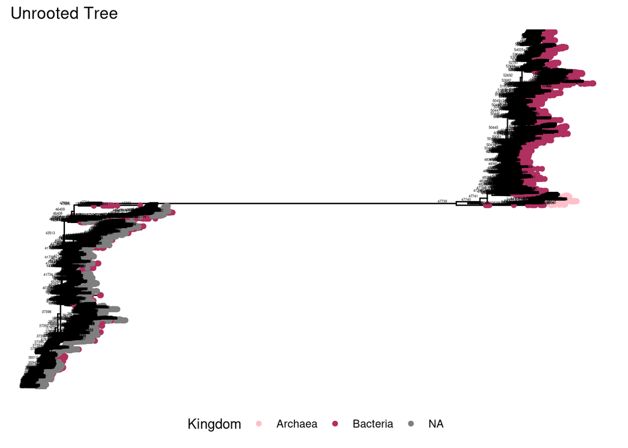

```r
kingdomnodetree <-
  kingdomtree + geom_text(aes(label=node), hjust= 2, vjust = -0.3, size = 1)

kingdomnodetree
```

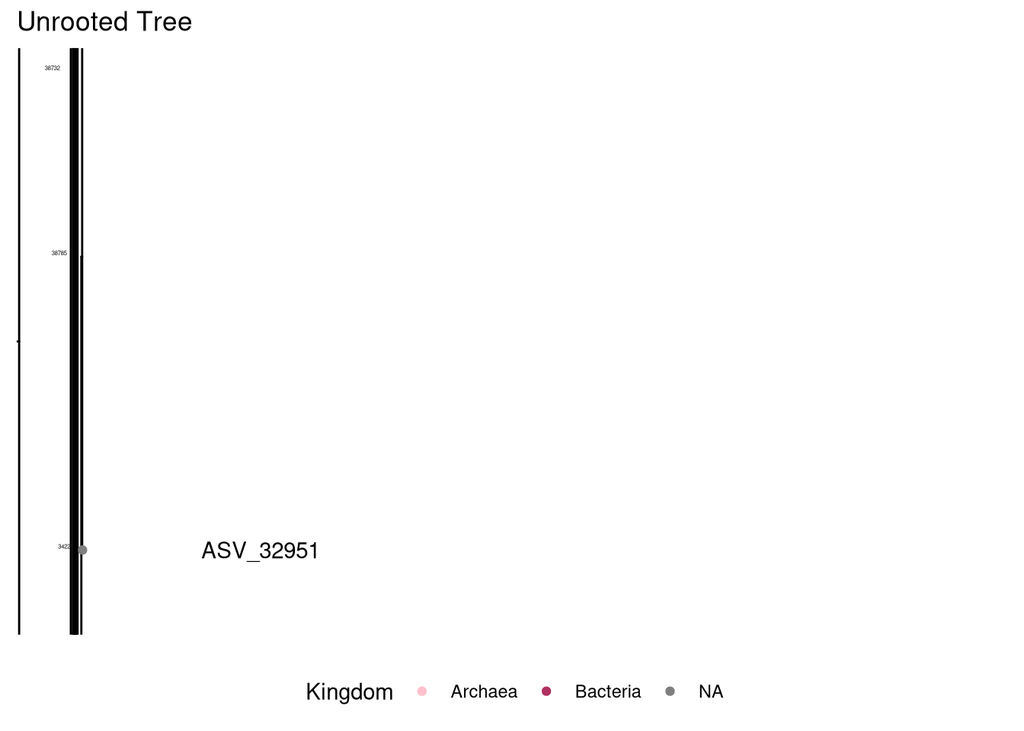

```r
# node 37398, 37395 in the middle of all the grey

node_number <- "37398"
node_number_2 <- "37395"

viewClade(kingdomnodetree +
          geom_text(aes(label=ASV), hjust=-1),
          node=node_number)
```

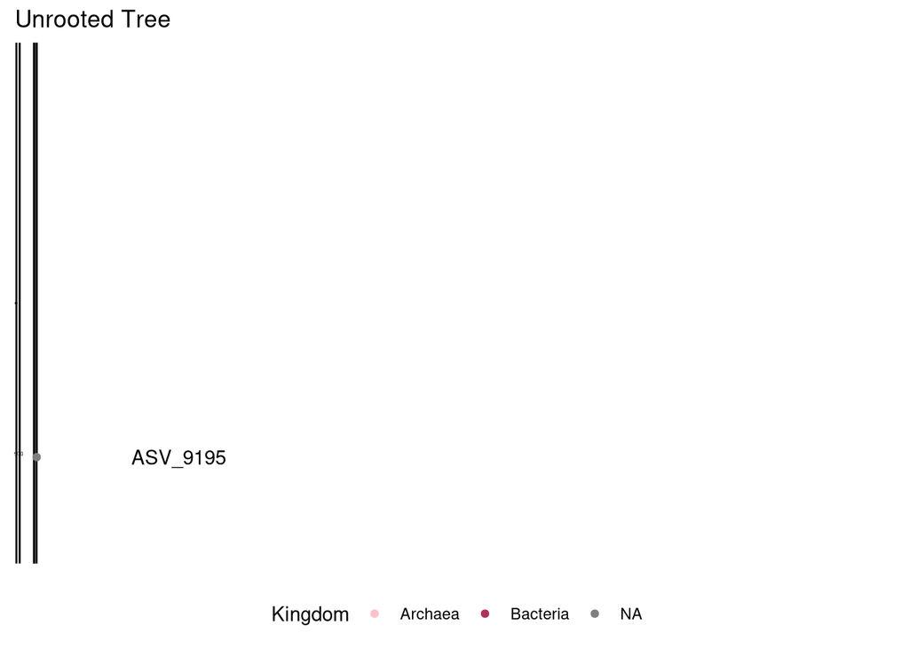

```r
#ASV 32951 ID'ed as a NA taxonomy asv

viewClade(kingdomnodetree +
          geom_text(aes(label=ASV), hjust=-1),
          node=node_number_2)
```

```r
#another NA ASV = 9195
```

## Extract sequences, examine in blast

```r
unrooted_physeq %>%
  subset_taxa(., ASV == "ASV_32951") %>%
  tax_table() %>%
  data.frame()
```

```
##           Kingdom Phylum Class Order Family Genus Species       ASV
## ASV_32951    <NA>   <NA>  <NA>  <NA>   <NA>  <NA>    <NA> ASV_32951
##                                                                                                                                                                                                                                                                                          ASVSeq
## ASV_32951 ACGGGTATCTAATCCCGTTTGCTCCCCTGGCTTTCGCGCCTCAGCGTCAGAAGAGATCCA…
```

```r
unrooted_physeq %>%
  subset_taxa(., ASV == "ASV_9195") %>%
  tax_table() %>%
  data.frame()
```

```
##          Kingdom Phylum Class Order Family Genus Species      ASV
## ASV_9195    <NA>   <NA>  <NA>  <NA>   <NA>  <NA>    <NA> ASV_9195
##                                                                                                                                                                                                                                                                                         ASVSeq
## ASV_9195 TGGGGTTTCTAATCCTGTTTGCTACCCACGCTTTCGTGTCTCAGCGTCAGTGATGGTCCA…
```

Blasted sequence results:

32951 is “uncultured Planctomycetes partial 16S rRNA gene”

9195 is “Uncultured bacterium clone OTU645_MIX3.66929 16S ribosomal RNA gene, partial sequence”

Looks like they are maybe “new taxa” or sequences not represented by the databases.

## Examine NA classification sequences - evaluate lengths before filtering

```r
## physeq object - clean_physeq

taxtable <-
  clean_physeq@tax_table %>%
  data.frame() %>%
  mutate(ASVlength = nchar(ASVSeq))


NA_kingdom <-
  clean_physeq %>%
  subset_taxa(., is.na(Kingdom)) %>%
  tax_table() %>%
  data.frame() %>%
  mutate(ASVlength = nchar(ASVSeq))

classified_kingdom <-
  clean_physeq %>%
  subset_taxa(., !is.na(Kingdom)) %>%
  tax_table() %>%
  data.frame() %>%
  mutate(ASVlength = nchar(ASVSeq))

NA_kingdom %>%
  count(ASVlength)
```

```
##   ASVlength    n
## 1       276   31
## 2       277 7857
## 3       278  646
## 4       279   12
## 5       280    6
```

```r
classified_kingdom %>%
  count(ASVlength)
```

```
##    ASVlength     n
## 1        262     2
## 2        263    19
## 3        264    17
## 4        265    73
## 5        266    17
## 6        267    28
## 7        268    11
## 8        269     8
## 9        273     5
## 10       274     7
## 11       275    23
## 12       276    94
## 13       277 24226
## 14       278  2072
## 15       279    72
## 16       280    85
## 17       281    10
## 18       282    12
## 19       287     1
## 20       288     1
## 21       289     1
## 22       290     1
```

```r
### CHECK IF MOST DOMINANT ASV IS REVERSE COMPLEMENT
```

## Remove NA classification sequences from physeq

```r
# physeq object from start of document
clean_physeq
```

```
## phyloseq-class experiment-level object
## otu_table()   OTU Table:         [ 35337 taxa and 72 samples ]
## sample_data() Sample Data:       [ 72 samples by 46 sample variables ]
## tax_table()   Taxonomy Table:    [ 35337 taxa by 9 taxonomic ranks ]
```

```r
clean_physeq %>%
  subset_taxa(., is.na(Kingdom)) %>%
  otu_table() %>%
  data.frame() %>%
  colSums()
```

```
## SRR19625066 SRR19625067 SRR19625068 SRR19625069 SRR19625070 SRR19625071
##        9192        8485       28958       19276       22124       13552
## SRR19625072 SRR19625073 SRR19625074 SRR19625075 SRR19625076 SRR19625077
##       15192       10969        8483       19193       21076       11844
## SRR19625078 SRR19625079 SRR19625080 SRR19625081 SRR19625082 SRR19625083
##       17962        8691        6564       17749       22177        7833
## SRR19625084 SRR19625085 SRR19625086 SRR19625087 SRR19625088 SRR19625089
##       25891       10641       17438       14530       12024       14442
## SRR19625090 SRR19625091 SRR19625092 SRR19625093 SRR19625094 SRR19625095
##       12868       10064       13375       13752       11255       15420
## SRR19625096 SRR19625097 SRR19625098 SRR19625099 SRR19625100 SRR19625101
##        3253        8308        6840       11673        6397        3409
## SRR19625102 SRR19625103 SRR19625104 SRR19625105 SRR19625106 SRR19625107
##       13352        6805       18810       13457       11656       10263
## SRR19625108 SRR19625109 SRR19625110 SRR19625111 SRR19625112 SRR19625113
##       15697        8666       20656        9905        4480       15906
## SRR19625114 SRR19625115 SRR19625116 SRR19625117 SRR19625118 SRR19625119
##       19995       13239       16771        7373       10068       12086
## SRR19625120 SRR19625121 SRR19625122 SRR19625123 SRR19625124 SRR19625125
##       19075       18889       10649       14069       21588       12510
## SRR19625126 SRR19625127 SRR19625128 SRR19625129 SRR19625130 SRR19625131
##       21189       12992        3022       11634        4530       38026
## SRR19625132 SRR19625133 SRR19625134 SRR19625135 SRR19625136 SRR19625137
##        8895       14733       11087       16588       15650       25408
```

```r
#Woah... that is a lot!!!! But still remove and examine tree.

filtered_physeq <- subset_taxa(clean_physeq, !is.na(tax_table(clean_physeq)[, "Kingdom"]))

# How many ASVs were removed?
clean_physeq
```

```
## phyloseq-class experiment-level object
## otu_table()   OTU Table:         [ 35337 taxa and 72 samples ]
## sample_data() Sample Data:       [ 72 samples by 46 sample variables ]
## tax_table()   Taxonomy Table:    [ 35337 taxa by 9 taxonomic ranks ]
```

```r
filtered_physeq
```

```
## phyloseq-class experiment-level object
## otu_table()   OTU Table:         [ 26785 taxa and 72 samples ]
## sample_data() Sample Data:       [ 72 samples by 46 sample variables ]
## tax_table()   Taxonomy Table:    [ 26785 taxa by 9 taxonomic ranks ]
```

```r
# 35337 starting taxa, 26785 ending taxa

print(c("The number of NA Kingdom taxa removed is:",35337-26785) )
```

```
## [1] "The number of NA Kingdom taxa removed is:"
## [2] "8552"
```

```r
print(c("The percentage of NA Kingdom taxa removed is", (35337-26785)/35337))
```

```
## [1] "The percentage of NA Kingdom taxa removed is"
## [2] "0.242012621331749"
```

# Run MAFFT again on filtered phyloseq

## Create NA-Filtered ASV Fasta file

```r
colnames(filtered_physeq@tax_table)
```

```
## [1] "Kingdom" "Phylum"  "Class"   "Order"   "Family"  "Genus"   "Species"
## [8] "ASV"     "ASVSeq"
```

```r
asv_seq_df_filtered <-
  filtered_physeq@tax_table %>%
  data.frame()%>%
  dplyr::select(ASV,ASVSeq)

# Make fasta headers
asv_seq_df_filtered$ASV <- paste0(">", asv_seq_df_filtered$ASV)

#create fasta object
asv_seq_fasta_filtered <- c(rbind(asv_seq_df_filtered$ASV, asv_seq_df_filtered$ASVSeq))
head(asv_seq_fasta_filtered)
```

```
## [1] ">ASV_1"
## [2] "CAGCCGCGGTAATACGTAGGGTGCGAGCGTTGTCCGGAATTACTGGGCGTAAAGAGCTCG…"
## [3] ">ASV_2"
## [4] "CAGCCGCGGTAATACGTAGGGTGCGAGCGTTGTCCGGAATTACTGGGCGTAAAGAGCTCG…"
## [5] ">ASV_3"
## [6] "CAGCCGCGGTAATACGTAGGGTGCGAGCGTTGTCCGGAATTACTGGGCGTAAAGAGCTCG…"
```

```r
#in fasta format now

# write to a file
write(asv_seq_fasta_filtered,
      file="data/04_phylogeny/asv_seqs_filtered.fasta")
```

## Align Filtered 16S sequences in fasta file

Note: need to run bash code for this step

```bash
# provide path to mafft
#export PATH=/programs/mafft/bin:$PATH
# change directories to fasta file
#cd data/04_phylogeny/
#pwd

# set seed
#RANDOM=0110

# Run mafft
#/programs/mafft/bin/mafft --auto asv_seqs_filtered.fasta > mafft_aligned_asvs_filtered.fasta

# back to project directory
#cd ../../
#pwd
```

## FastTree2 on filtered and aligned fasta

```bash
# fasttree export path
#export PATH=/programs/FastTree-2.1.11:$PATH

#switch directory
#cd data/04_phylogeny/

#run fasttree
#dataset is very large, use fastest

#FastTree -nt -gtr -fastest -log FastTree.log mafft_aligned_asvs_filtered.fasta > asvs_unrooted_filtered.tree

#cd to main directory
#cd ../../
#pwd
```

## load in filtered aligned tree

```r
unrooted_filtered_tree <- read.tree("data/04_phylogeny/asvs_unrooted_filtered.tree")
unrooted_filtered_tree
```

```
##
## Phylogenetic tree with 26785 tips and 26783 internal nodes.
##
## Tip labels:
##   ASV_7364, ASV_9136, ASV_21802, ASV_10521, ASV_13100, ASV_19762, ...
## Node labels:
##   , 0.242, 0.722, 0.000, 0.861, 0.000, ...
##
## Unrooted; includes branch lengths.
```

## merge filtered phyloseq

```r
unrooted_physeq_filtered <-
  merge_phyloseq(filtered_physeq, unrooted_filtered_tree)

unrooted_physeq
```

```
## phyloseq-class experiment-level object
## otu_table()   OTU Table:         [ 35337 taxa and 72 samples ]
## sample_data() Sample Data:       [ 72 samples by 46 sample variables ]
## tax_table()   Taxonomy Table:    [ 35337 taxa by 9 taxonomic ranks ]
## phy_tree()    Phylogenetic Tree: [ 35337 tips and 35335 internal nodes ]
```

## plot filtered tree with ggtree

Viewing tree without ASV labels because there are so many it becomes illegible

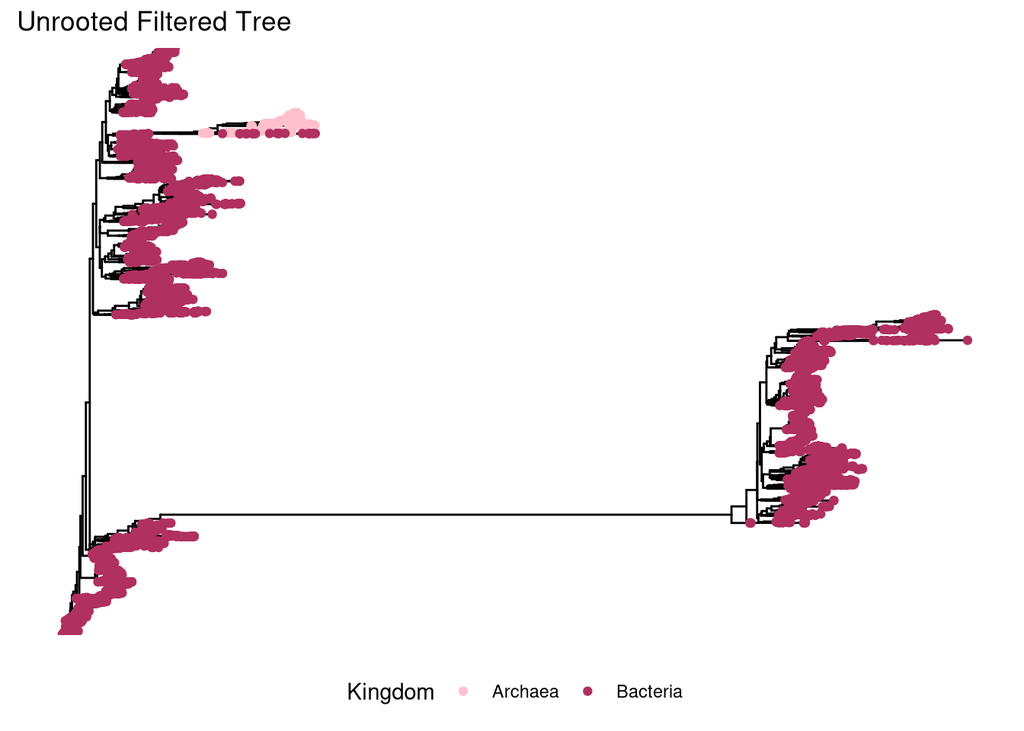

```r
filtered_kingdomtree <-
  ggtree(unrooted_physeq_filtered)  +
  geom_tippoint(mapping = aes(color = Kingdom)) +
  scale_color_manual(values = c("pink", "maroon")) +
  labs(title = "Unrooted Filtered Tree") +
  theme(legend.position = "bottom")

filtered_kingdomtree
```

There is still a crazy separation happening, even after removing the unclassified sequences.

# Root Both trees

## Rooting unfiltered

```r
unfiltered_tree_toroot <- phy_tree(unrooted_physeq)

is.rooted(unfiltered_tree_toroot)
```

```
## [1] FALSE
```

```r
midpoint_rooted_unfiltered_tree <-
  midpoint.root(unfiltered_tree_toroot)

is.rooted(midpoint_rooted_unfiltered_tree)
```

```
## [1] TRUE
```

## Viewing unfiltered tree

```r
unfiltered_rooted_tree_physeq <-
  merge_phyloseq(clean_physeq, midpoint_rooted_unfiltered_tree)

unrooted_physeq
```

```
## phyloseq-class experiment-level object
## otu_table()   OTU Table:         [ 35337 taxa and 72 samples ]
## sample_data() Sample Data:       [ 72 samples by 46 sample variables ]
## tax_table()   Taxonomy Table:    [ 35337 taxa by 9 taxonomic ranks ]
## phy_tree()    Phylogenetic Tree: [ 35337 tips and 35335 internal nodes ]
```

```r
midpoint_rooted_unfiltered_tree
```

```
##
## Phylogenetic tree with 35337 tips and 35336 internal nodes.
##
## Tip labels:
##   ASV_1972, ASV_4009, ASV_1476, ASV_313, ASV_1004, ASV_14664, ...
## Node labels:
##   , 0.922, 0.174, 0.000, 0.922, 0.922, ...
##
## Rooted; includes branch lengths.
```

```r
unfiltered_rooted_tree_physeq
```

```
## phyloseq-class experiment-level object
## otu_table()   OTU Table:         [ 35337 taxa and 72 samples ]
## sample_data() Sample Data:       [ 72 samples by 46 sample variables ]
## tax_table()   Taxonomy Table:    [ 35337 taxa by 9 taxonomic ranks ]
## phy_tree()    Phylogenetic Tree: [ 35337 tips and 35336 internal nodes ]
```

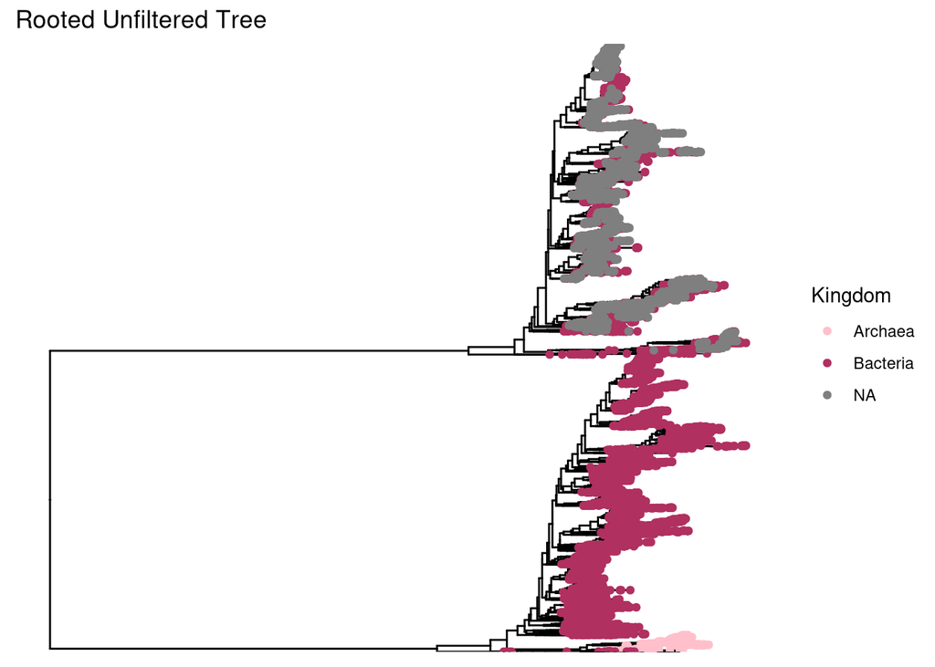

```r
ggtree(unfiltered_rooted_tree_physeq) +
  geom_tippoint(mapping=aes(color=Kingdom))+
  labs(title="Rooted Unfiltered Tree")+
  scale_color_manual(values = c("pink", "maroon"))
```

## Rooting filtered

```r
filtered_tree_toroot <- phy_tree(unrooted_physeq_filtered)

is.rooted(filtered_tree_toroot)
```

```
## [1] FALSE
```

```r
midpoint_rooted_filtered_tree <-
  midpoint.root(filtered_tree_toroot)

is.rooted(midpoint_rooted_filtered_tree)
```

```
## [1] TRUE
```

```r
filtered_rooted_tree_physeq <-
  merge_phyloseq(filtered_physeq, midpoint_rooted_filtered_tree)
```

## Viewing filtered tree

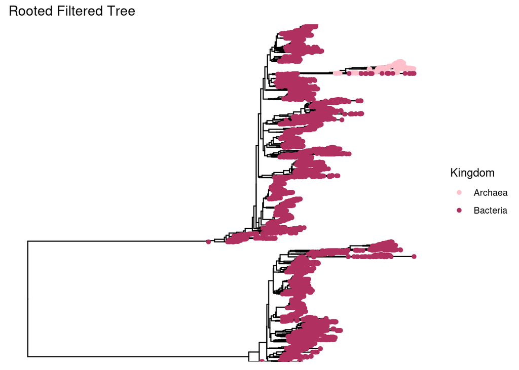

```r
ggtree(filtered_rooted_tree_physeq) +
  geom_tippoint(mapping=aes(color=Kingdom))+
  scale_color_manual(values = c("pink", "maroon")) +
  labs(title="Rooted Filtered Tree")
```

Filtering vs not filtering the tree both result in a weird, split tree. Almost all sequences on both halves of the rooted tree are the exact same length, so I am not really sure what is happening here or what to make of this data!!

## Save phyloseq objects

```r
save(list = c("unrooted_physeq", #unrooted physeq
              "unrooted_physeq_filtered", #unrooted filtered physeq
              "unfiltered_rooted_tree_physeq", #rooted tree
              "filtered_rooted_tree_physeq"), #rooted filtered tree
              file = "data/04_phylogeny/phytree_preprocessed_physeq.RData")
```